# Bayesian Additive Regression Trees for Multivariate skewed responses

Seungha Um

July 25, 2022

# Introduction

This vignette demonstrates how to fit the skewBART model using the `skewBART` package. The small MCMC iterations and tree numbers are used to reduce computation time; in practice, larger values (say, 200 trees and 5000 MCMC iterations) should be used. Our model is an extension of BART to accommodate univariate and multivariate skewed responses.

First, we load the requisite packages:

```r
## Load library
library(tidyverse) # Load the tidyverse, mainly for ggplot
library(kableExtra) # For fancy tables
library(skewBART) # Our package
library(zeallot) # For the %<-% operator, used when generating data
options(knitr.table.format = 'markdown')
```

# Univariate skewed response

We first illustrate on a simple example due to Friedman which takes
$$f(x) = 10 \sin(\pi \, x_1 \, x_2) + 20 (x_3 - 0.5)^2 + 10 x_4 + 5 x_5.$$
We set $Y_i = f(x_i) + \epsilon_i$ with $\epsilon_i$ have a skew-normal distribution with scale $\sigma = 3$ and shape $\alpha = 1$.

## Setup

The following code creates a function to simulate data from the model.

```r
## Create a function for Friedman’s example
sim_fried <- function(N, P, alpha, sigma) {
  lambda <- alpha * sigma/sqrt(1+alpha^2)
  tau <- sigma/sqrt(1+alpha^2)
  X <- matrix(runif(N * P), nrow = N)
  mu <- 10 * sin(pi * X[,1] * X[,2]) + 20 * (X[,3] - 0.5)^2 + 10 * X[,4] + 5 * X[,5]
  Z <- abs(rnorm(N, mean=0, sd=1) )
  Y <- mu + lambda * Z + rnorm(N, mean=0, sd=sqrt(tau))
  EY <- mu + lambda * sqrt(2/pi)
  return(list(X = X, Y = Y, EY = EY, mu = mu, Z=Z, tau = tau, lambda = lambda))
}
```

We then create a training set and testing set:

```r
## Traning dataset : n = 100 observations, P = 5 covariates, sigma = 1, alpha = 3
set.seed(12345)
c(X,Y,EY,mu,Z,tau,lambda) %<-% sim_fried(100, 5, 1, 3)
c(test_X,test_Y,test_EY,test_mu,test_Z,test_tau,test_lambda)  %<-% sim_fried(50, 5, 1 ,3)
```

Next, we create an object containing the hyperparameters for the model using the `UHypers` function (U is for univariate, as opposed to multivariate). This function uses default hyperparameters unless specific hyperparameters are provided by the user; see `?UHypers` for more details.

```r
hypers <- UHypers(X, Y, num_tree = 20)
opts <- UOpts(num_burn = 250, num_save = 250)
```

The function `UOpts` produces a list of the parameters for running the Markov chain for univariate skewBART model. For illustration we use only 250 burn-in and save iterations; the defaults are 2500 for each. `UOpts` can also be used to control some features of the chain, such as whether hyperparameters are updated.

## Fitting the skewBART model

After creating the hyperparameters and options, we fit the data by running

```r
## Fit the model
fitted_skewbart <- skewBART(X = X, Y = Y, test_X = test_X,
                            hypers = hypers, opts = opts)
Finishing iteration 100 of 500
Finishing iteration 200 of 500
Finishing iteration 300 of 500
Finishing iteration 400 of 500
Finishing iteration 500 of 500
```

## Contents of the model fit

The fitted model is a list containing the following elements:

- `y_hat_train`: samples with `num_save` rows containing samples of the estimated mean for each observation in the training set.
- `y_hat_test`: same as `y_hat_train`, but for the testing set.
- `y_hat_train_mean`: the posterior mean of the predicted value of each observation on the training set; this includes both the prediction from the BART model and an offset due to the fact that the skew-normal distribution does not have mean 0.
- `y_hat_test_mean`: same as `y_hat_train_mean` but on the testing set.
- `f_hat_train` and `f_hat_test` are analogous to `y_hat_train` and `y_hat_test`, but just give the value of the BART function - for BART these are the same quantity, but for skewBART we need to account for the fact that the errors do not have mean 0.
- `sigma`: posterior samples of parameter $\sigma$ in the skew-normal error.
- `tau`: posterior samples of parameter $\tau$ in the skew-normal error.
- `alpha`: posterior samples of parameter $\alpha$ in the skew-normal error.
- `lambda`: posterior samples of parameter $\lambda$ in the skew-normal error.

The parameters $(\lambda, \tau)$ and $(\alpha, \sigma)$ give equivalent descriptions of the skew-normal distribution, and are related by the fact that $\lambda = \alpha\sigma / \sqrt{1 + \alpha^2}$ and $\tau = \sigma / \sqrt{1 + \alpha^2}$; the MCMC is run on $(\lambda, \tau)$, but the skew-normal (with location parameter $0$) is typically parameterized in terms of $(\alpha,\sigma)$ as
$$p(y) = \frac{2}{\sigma} \phi\left(\frac{y}{\sigma}\right) \, \Phi\left(\alpha \frac{y}{\sigma}\right).$$
So, for example, the posterior mean of the skewness level $\alpha$ is

```r
mean(fitted_skewbart$alpha)
```

```
#> [1] 1.234029
```

while the posterior mean of the predicted values on the test data is

```r
fitted_skewbart$y_hat_test_mean
```

```
#>  [1] 21.496757 18.970176 21.265690 15.686706 12.752259  6.528893 17.201093
#>  [8] 14.874383 19.829890 14.558336 21.393249 17.643906 20.784597 17.235449
#> [15] 18.471866 16.609551 16.427583 16.149990 13.901739 21.684180 16.467493
#> [22] 10.759891 18.550183 19.530057 20.546503 17.385725 14.769446 10.613898
#> [29] 16.417687 14.435709 14.579232 21.389135 14.625900 12.567851 13.911232
#> [36] 11.412305 11.360358 14.786439 22.117861  7.963105 25.696364 14.732274
#> [43] 10.703877 21.609107  5.451018 19.051942 11.362971 11.093244 21.984574
#> [50]  4.704579
```

Below, we assess the mixing of the model with a traceplot (left) and plot the fitted versus actual values (right) of $f(x)$.

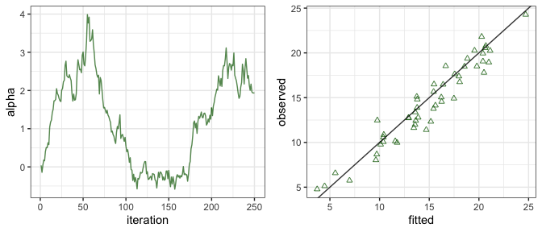

```r
# create a dataframe for the estimated alpha
df <- data.frame(iteration = 1:length(fitted_skewbart$alpha), alpha=fitted_skewbart$alpha)
p1 <- ggplot(df) + geom_line(aes(iteration, alpha), color = "darkgreen", alpha=0.7) + theme_bw()

# create a dataframe for the fitted values
df_fitted <- data.frame(fitted = fitted_skewbart$f_hat_test_mean, observed = test_mu)
p2 <- ggplot(df_fitted) +
  geom_point(aes(fitted, observed), alpha=0.8, shape=2, color = "darkgreen") +
  geom_abline(intercept = 0, slope = 1, alpha=0.8) +
  theme_bw()
library(ggpubr)
ggarrange(p1, p2)
```

# Multivariate skewed response

## Setup

The following code creates a function for generating the data.

```r
## Create a function for Friedman example with multivariate framework
sim_data_multi <- function(N, P, lambda, tau, rho) {
  X <- matrix(runif(N * P), nrow = N)
  mu <- 10 * sin(pi * X[,1] * X[,2]) + 20 * (X[,3] - 0.5)^2 + 10 * X[,4] + 5 * X[,5]
  Z <- cbind(lambda[1] * abs(rnorm(N)), lambda[2] * abs(rnorm(N)))
  Sigma <- matrix(c(tau[1], sqrt(tau[1]*tau[2])*rho, sqrt(tau[1]*tau[2])*rho, tau[2]), 2, 2)
  Err <- MASS::mvrnorm(n=N, mu=c(0,0), Sigma = Sigma)
  Y <- cbind(mu, mu) + Z + Err
  EY <- rbind(mu, mu) + lambda * sqrt(2/pi)
  return( list(X = X, Y = Y, EY=EY, mu = mu, lambda = lambda, tau=tau, Z= Z, Sigma = Sigma) )
}
```

We then create the training and testing sets.

```r
## Simulate dataset
## Traning dataset : n = 100 observations, P = 5 covariates,
## lambda = (2,3), tau = c(1,1), rho = 0.5.
set.seed(12345)
c(X,Y,EY,mu,lambda,tau,Z,Sigma) %<-% sim_data_multi(100, 5, c(2,3), c(1,1), 0.5)
c(test_X,test_Y,test_EY,test_mu,test_lambda,test_tau,test_Z,test_Sigma) %<-%
  sim_data_multi(50, 5, c(2,3), c(1,1), 0.5)
```

The functions `Hypers` and `Opts` are the multivariate extensions of `UHypers` and `UOpts`. We use these to set the hyperparameters and MCMC options.

```r
## Create a list of the hyperparameters of the model.
hypers <- Hypers(X = X, Y = Y, num_tree = 20)
opts <- Opts(num_burn = 50, num_save = 50)
```

## Fitting the multi-skewBART model

The model is fit using the `MultiskewBART` function:

```r
fitted_Multiskewbart <- MultiskewBART(X = X, Y = Y, test_X = test_X, hypers=hypers, opts=opts)
Finishing iteration 100 of 100
```

## Contents of the Model Fit

The model fit contains quantities analogous to a univariate skewBART fit, but now the dimension of the objects is different. For example. `y_hat_train` is now an $N \times 2 \times$ `num_save` array, $\Sigma$ is a $2 \times 2 \times$ `num_save` array, and so forth. We can get the posterior mean of $\lambda_1$ and $\lambda_2$ by computing

```r
mean(fitted_Multiskewbart$lambda[,1])
```

```
#> [1] 1.563386
```

```r
mean(fitted_Multiskewbart$lambda[,2])
```

```
#> [1] 2.618475
```

while the posterior mean of the function fit to the testing data is given by

```r
head(fitted_Multiskewbart$f_hat_test_mean)
```

```
#>           [,1]      [,2]
#> [1,]  7.061399  6.823013
#> [2,] 23.434735 22.865948
#> [3,] 12.497494 11.782423
#> [4,] 19.658088 19.530547
#> [5,] 22.964786 22.594777
#> [6,] 19.498565 17.811530
```

As before, we can examine the mixing of the skewness parameters $(\lambda_1, \lambda_2)$ by running

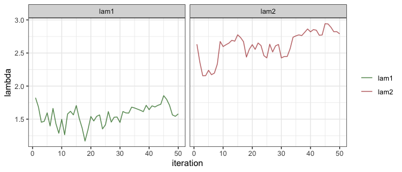

```r
# create a dataframe for estimated skewness levels (lambda)
df <- data.frame(iteration = 1:length(fitted_Multiskewbart$lambda[,1]),
                 lambda = c(fitted_Multiskewbart$lambda[,1], fitted_Multiskewbart$lambda[,2]),
                 grp = rep(c("lam1","lam2"), each=length(fitted_Multiskewbart$lambda[,1])))

ggplot(df) + geom_line(aes(iteration, lambda, colour=grp), alpha=0.7) +
  theme_bw() + facet_wrap(~grp) +
  scale_colour_manual(values=c(lam1 = "darkgreen", lam2= "brown")) +
  theme(legend.title=element_blank())
```

and plot of the fitted vs actual values by running

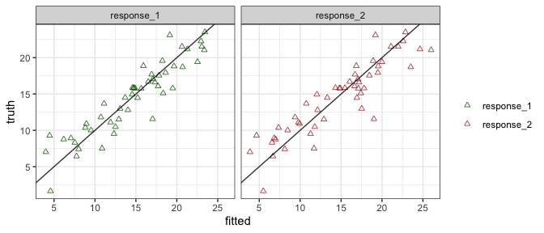

```r
df_fitted <- data.frame(fitted = c(fitted_Multiskewbart$f_hat_test_mean),
                        truth = rep(test_mu, 2),
                        grp = rep(c("response_1", "response_2"),each = length(test_mu)))

ggplot(df_fitted) + geom_point(aes(fitted, truth, colour=grp), alpha=0.8, shape=2) +
  geom_abline(intercept = 0, slope = 1, alpha=0.8) +
  scale_colour_manual(values=c(response_1 = "darkgreen", response_2= "brown")) +
  theme_bw() + facet_wrap(~grp) + theme(legend.title=element_blank())
```